# Kodutöö 1

## Kodutöö esitamise õpetus

Iga ülesande lahendus peaks mahtuma ühte või mitmesse koodiaknasse, selle ülesande all. See kood võiks olla nii kirjutatud, et saaks käima tõmmata ilma mõtlemata. See tähendab, et kõik vajalikud lisapaketid ja andmestikud loetakse sisse vastavas koodiaknas.

Esita kogu kodutöö kataloog zip failina meili aadressil **raivo.kolde@ut.ee.** Kirja pealkirjaks pane **LTAT.02.008 Kodutöö 1.** Tähtaeg on *22. märts 23.59 EET.*

## Ülesanne 1

Kasutades grid paketi käske joonista `eyecolor` andmestik välja tulpdiagrammina. Kas tulbad on kõrvuti, üksteise otsas, jagatud tahkudeks või leitud mõni muu lahendus jääb juba enda otsustada.

Vihje: kasuta ära võimalikult palju praktikumi koodi

```r
library(grid)
library(tidyverse)
```

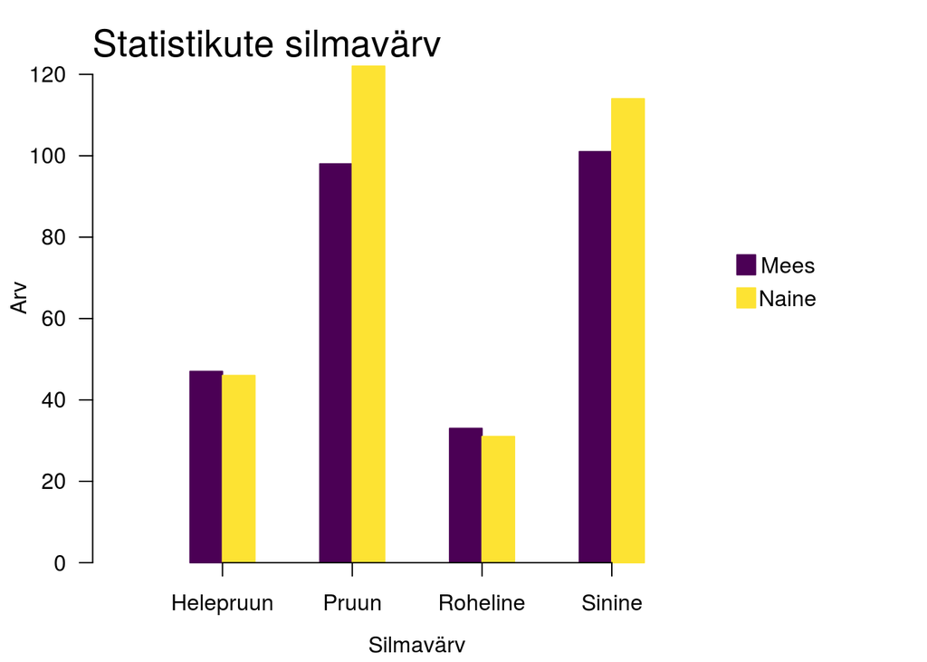

```r
eyecolor = tibble(
  eye = c("Pruun", "Pruun", "Sinine", "Sinine", "Helepruun", "Helepruun", "Roheline", "Roheline"),
  gender = c("Mees", "Naine", "Mees", "Naine", "Mees", "Naine", "Mees", "Naine"),
  count = c(98, 122, 101, 114, 47, 46, 33, 31)
)

eyecolor <- eyecolor %>%
  mutate(eye_scaled = as.numeric(as.factor(eye))/(length(unique(eye))+1)) %>%
  mutate(gndr_scaled = (as.numeric(factor(gender))-1)/length(unique(gender))*0.1) %>%
  mutate(eye_gndr_scaled = eye_scaled+gndr_scaled) %>%
  mutate(gender_color = hcl.colors(2)[gender %>% as.factor() %>% as.numeric()]) %>%
  mutate(count_scaled = count / max(count))

grid.newpage()

# Legend
pushViewport(viewport(x = 0.8, y = 0, height = 1, width = 0.2, just = c(0, 0)))
grid.rect(x = 0.025, y = 0.55, height = 0.03, width =0.1,
          gp = gpar(col = hcl.colors(2)[2], fill = hcl.colors(2)[2]))
grid.rect(x = 0.025, y = 0.60, height = 0.03, width =0.1,
          gp = gpar(col = hcl.colors(2)[1], fill = hcl.colors(2)[1]))
grid.text(label = "Naine", x = 0.25, 0.55)
grid.text(label = "Mees", x = 0.25, 0.6)
popViewport()

# Graafik
pushViewport(viewport(x = 0.8, y = 0.9, height = 0.75, width = 0.7, just = c(1, 1)))
grid.rect(x = eyecolor$eye_gndr_scaled, y = 0, just = c(1,0), height = eyecolor$count_scaled, width = 0.05, gp = gpar(col = eyecolor$gender_color, fill = eyecolor$gender_color))
grid.xaxis(at = c(0.2, 0.4, 0.6, 0.8), label = c("Helepruun", "Pruun", "Roheline", "Sinine"))
grid.yaxis(at = grid.pretty(c(0, 122))/ max(eyecolor$count), label = grid.pretty(c(0, 122)))
popViewport()

# Pealkiri
pushViewport(viewport(x = 0.8, y = 0.9, height = 0.1, width = 0.7, just = c(1, 0)))
grid.text(x = 0, y = 0.15, label = "Statistikute silmavärv", just = c(0, 0), gp = gpar(fontsize = 20))
popViewport()

# x - telg
pushViewport(viewport(x = 0.8, y = 0.15, height = 0.15, width = 0.7, just = c(1, 1)))
grid.text(x = 0.5, y = 0.1, label = "Silmavärv", just = c(0.5, 0))
popViewport()

# y - telg
pushViewport(viewport(x = 0, y = 0.15, height = 0.75, width = 0.1, just = c(0, 0)))
grid.text(x = 0.2, y = 0.5, label = "Arv", just = c(0, 0.5), rot = 90)
popViewport()
```

## Ülesanne 2

Proovi joonistada võimalikult sarnane graafik järgnevaga, lasutades andmestikku `linnad.RData`. Siin on rakendatud terve hulk nippe. mida sai antud praksis õpitud. Punktid kujunevad selle põhjal kui palju neist nippidest on rakendatud. Kui õiget nippi on rakendatud, kuid tulemus pole täpselt identne, siis punkte maha ei võta. Näiteks kui värv pole täpselt õige aga õigel graafiku osal on seda siiski muudetud.

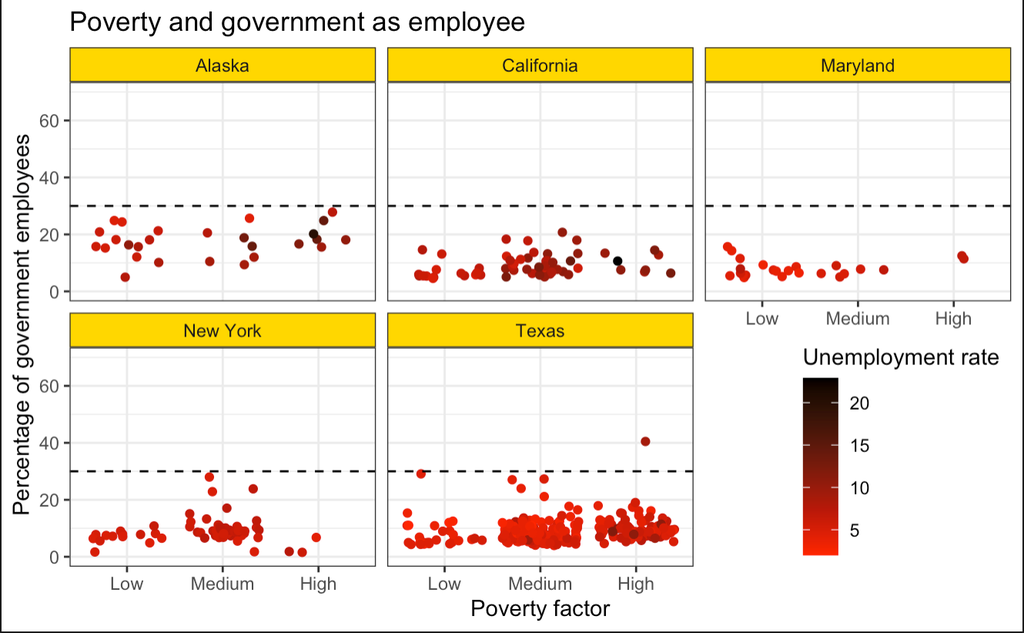

```r
library(ggplot2)
library(tidyverse)

load("linnad.RData", verbose = T)
```

```
## Loading objects:
##   linnad
```

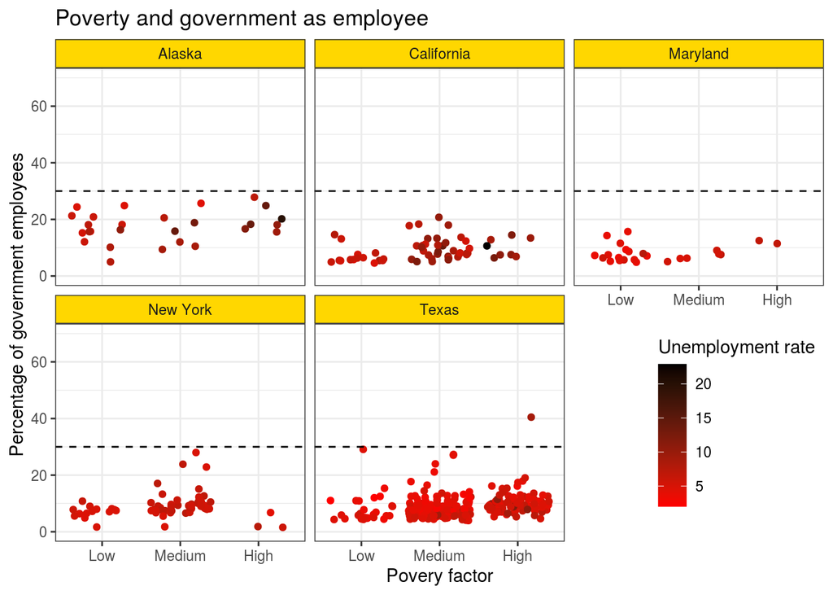

```r
ggplot(linnad, aes(x=factor(Poverty_factor, levels=c("Low", "Medium", "High")), y = govt_employed, color = unemployment_rate))+
  geom_point(position = "jitter")+
  ggtitle("Poverty and government as employee")+
  xlab("Povery factor")+
  scale_y_continuous(name = "Percentage of government employees", limits = c(0,70), breaks = c(0,20,40,60))+
  scale_colour_gradient(name = "Unemployment rate", low = "red", high = "black", breaks = c(5, 10, 15, 20))+
  geom_hline(yintercept = 30, linetype = "dashed") +
  facet_wrap(~State) +
  theme_bw()+
  theme(legend.position = c(1,0.45), legend.justification = c(1, 1),
        strip.background =element_rect(fill="#FFD700"))
```

## Ülesanne 3

Meil on andmestik erinevate maailma riikide ning nende sotsiaalsete indeksite kohta. See andmestik on failis `countries.RData` mis on kaasas praktikumi materjalidega. Sellel andmestikul tuleks uurida küsimust, kas ja milline on seos laste arvul naise kohta (`child_per_woman`) oodatava elueaga (`life_expectancy`). Sealjuures tuleks pildil arvesse võtta ka riikide populatsiooni (`population_total`), maailmajagu (`region`) ning jaotust sissetuleku järgi (`income_groups`). Kõik muutujad võib panna ühele pildile või võib kombineerida ka mitmest panellist patchworki kasutades. Kuna andmed on keerukad võib pildi salvestada suuremana (kasutades käsku `ggsave` ja argumente `height` ja `width`), et kõigel vajalikul piisavalt ruumi oleks.

Esitada tuleb graafikut genereeriv **kood** ja ka mõne lauseline **järeldus**, mille te pildilt olete välja lugenud.

Hindame järgnevaid aspekte

- Järelduse asjakohasus ja kui lihtne on seda pildiga kokku viia
- Graafiku(te) joonistamisel tehtud valikute asjakohasus
- Graafilised detailid ja nende valik
  - Värviskaalad
  - Diskreetsete muutujate järjekord
  - Kõik tekstid pildil võiksid olla kergesti loetavad (suurte tähtedega, grammatiliselt korrektsed, piisavalt kirjeldavad)

```r
library(ggplot2)
library(tidyverse)
library(RColorBrewer)
library(patchwork)
library(sjmisc)
load("countries.RData", verbose = T)
```

```
## Loading objects:
##   countries
```

```r
#populatsioonid kvantiilide põhjal 4ks kategooriaks
countries$pop_grouped <- split_var(countries$population_total, n = 4)

#eralduskohad
splits <- prettyNum(quantile(countries$population_total, c(.25,.50,.75,1), names = FALSE),big.mark=",", scientific = FALSE)

#Populatsioonikategooriate nimed
nimed <- c(paste0("0-",splits[1]),
           paste0(splits[1],"-",splits[2]),
           paste0(splits[2],"-",splits[3]),
           paste0(splits[3],"-",splits[4]))

countries$pop_grouped <- factor(countries$pop_grouped, labels = nimed)

#Muude tunnuse faktorite järjestus ja nimed
countries <- countries %>%
  mutate(income_groups = factor(income_groups, levels = c("low_income", "lower_middle_income",
                                                          "upper_middle_income", "high_income"))) %>%
  mutate(income_groups_est = recode(income_groups,  low_income = "Madal sissetulek",  lower_middle_income = "Madal keskmine sissetulek",
                                 upper_middle_income = "Kõrge keskmine sissetulek",  high_income = "Kõrge sissetulek")) %>%
  mutate(region_est = recode(region,  africa = "Aafrika",  americas = "Ameerika",
                                 asia = "Aasia",  europe = "Euroopa"))

#Üldine graafik
general <- ggplot(countries, aes(x=child_per_woman, y = life_expectancy))+
  geom_point(aes(shape = region_est, size = log(population_total), color = income_groups_est), alpha = 0.7)+
  geom_smooth(method="lm")+
  xlab(label = "Lapsi naise kohta")+
  ylab(label = "Oodatav eluiga")+
  scale_colour_manual(values = c("#ffffb2", "#fecc5c", "#fd8d3c", "#e31a1c"))+
  theme(panel.background = element_rect(fill = "gray15"))+
  theme(plot.background = element_rect(fill = "lightgray",
                                       colour = "gray30",
                                       size = 2))+
  theme(legend.background = element_rect(fill= "lightgray"))+
  theme(axis.text.x = element_text(face = "bold",
                                   color = "black",
                                   size = 10),
          axis.text.y = element_text(face = "bold",
                                     color = "black",
                                     size = 10))+
  theme(axis.title.x = element_text(face = "bold", color = "black",
                           size = 12),
          axis.title.y = element_text(face = "bold", color = "black",
                           size = 12))+
  theme(legend.key=element_rect(fill = "gray30"),
        legend.key.size = unit(2,"line"),
        legend.title=element_text(size=15),
        legend.text=element_text(size=13))+
  theme(legend.position = c(1,1),
        legend.justification = c(1, 1),
        legend.box = "horizontal")+
  guides(shape = guide_legend(override.aes = list(size=4)))+
  guides(colour = guide_legend(override.aes = list(size=4)))+
  labs(color = "Sissetulek", fill = "Sissetulek", size = "log(populatsioon)", shape = "Piirkond")+
  ggtitle(label = "Suhe laste arvu ja oodatava eluea vahel")

#Sissetulekut arvestav graafik
incm_plt <- ggplot(countries, aes(x=child_per_woman, y = life_expectancy, color = income_groups_est))+
    geom_point(alpha = 0.7, size = 3)+
    geom_smooth(aes(fill = income_groups_est), method="lm")+
    xlab(label = "Lapsi naise kohta")+
    ylab(label = "Oodatav eluiga")+
    scale_colour_manual(values = c("#ffffb2", "#fecc5c", "#fd8d3c", "#e31a1c"))+
    scale_fill_manual(values = c("#ffffb2", "#fecc5c", "#fd8d3c", "#e31a1c"))+
    theme(panel.background = element_rect(fill = "gray15"))+
    theme(plot.background = element_rect(fill = "lightgray", colour = "gray30", size = 2))+
    theme(legend.background = element_rect(fill= "lightgray"))+
    theme(legend.position = c(1,1), legend.justification = c(1, 1))+
    theme(axis.text.x = element_text(face = "bold", color = "black",
                           size = 10),
          axis.text.y = element_text(face = "bold", color = "black",
                           size = 10))+
    theme(axis.title.x = element_text(face = "bold", color = "black",
                           size = 12),
          axis.title.y = element_text(face = "bold", color = "black",
                           size = 12))+
    theme(legend.key=element_rect(fill = "gray30"),
          legend.key.size = unit(2,"line"),
          legend.title=element_text(size=12),
          legend.text=element_text(size=10))+
    guides(size=FALSE)+
    labs(color = "Sissetulek", fill = "Sissetulek")+
    ggtitle(label = "Suhe laste arvu ja oodatava eluea vahel \narvestades sissetulekuga")

#Piirkonda arvestav graafik
rgn_plt <- ggplot(countries, aes(x=child_per_woman, y = life_expectancy, colour = region_est))+
    geom_point(aes(shape = region_est), alpha = 0.7, size = 4)+
    geom_smooth(aes(fill = region_est), method="lm")+
    xlab(label = "Lapsi naise kohta")+
    ylab(label = "Oodatav eluiga")+
    scale_colour_brewer(palette = "Dark2")+
    scale_fill_brewer(palette = "Dark2")+
    theme(panel.background = element_rect(fill = "gray15"))+
    theme(plot.background = element_rect(fill = "lightgray", colour = "gray30", size = 2))+
    theme(legend.background = element_rect(fill= "lightgray"))+
    theme(legend.position = c(1,1), legend.justification = c(1, 1), legend.box = "horizontal")+
    theme(axis.text.x = element_text(face = "bold", color = "black",
                           size = 10),
          axis.text.y = element_text(face = "bold", color = "black",
                           size = 10))+
    theme(axis.title.x = element_text(face = "bold", color = "black",
                           size = 12),
          axis.title.y = element_text(face = "bold", color = "black",
                           size = 12))+
    theme(legend.key=element_rect(fill = "gray30"),
          legend.key.size = unit(2,"line"),
          legend.title=element_text(size=15),
          legend.text=element_text(size=13))+
    theme(legend.key.size = unit(2,"line"))+
    labs(colour = "Piirkond", shape = "Piirkond", fill = "Piirkond")+
    guides(size = FALSE)+
    ggtitle(label = "Suhe laste arvu ja oodatava eluea vahel \narvestades piirkonnaga")

#Populatsiooni arvestav graafik
pop_plt <- ggplot(countries, aes(x=child_per_woman, y = life_expectancy, color = pop_grouped))+
    geom_point(aes(size = log(population_total)), alpha = 0.7)+
    geom_smooth(aes(fill = pop_grouped), method="lm")+
    xlab(label = "Lapsi naise kohta")+
    ylab(label = "Oodatav eluiga")+
    scale_colour_manual(values = c("#ffffcc", "#a1dab4", "#41b6c4", "#225ea8"))+
    scale_fill_manual(values = c("#ffffcc", "#a1dab4", "#41b6c4", "#225ea8"))+
    theme(panel.background = element_rect(fill = "gray15"))+
    theme(plot.background = element_rect(fill = "lightgray", colour = "gray30", size = 2))+
    theme(legend.background = element_rect(fill= "lightgray"))+
    theme(legend.position = c(1,1), legend.justification = c(1, 1), legend.box = "horizontal")+
    theme(axis.text.x = element_text(face = "bold", color = "black",
                           size = 10),
          axis.text.y = element_text(face = "bold", color = "black",
                           size = 10))+
  theme(axis.title.x = element_text(face = "bold", color = "black",
                           size = 12),
          axis.title.y = element_text(face = "bold", color = "black",
                           size = 12))+
    theme(legend.key=element_rect(fill = "gray30"),
          legend.key.size = unit(1,"line"),
          legend.title=element_text(size=12),
          legend.text=element_text(size=10))+
    labs(size = "log(populatsioon)", fill = "Populatsiooni vahemik", color = "Populatsiooni vahemik") +
    ggtitle(label = "Suhe laste arvu ja oodatava eluea vahel \narvestades populatsiooniga")

board <- general / (incm_plt | rgn_plt | pop_plt)

ggsave("kodutoo_regression.png", board, width = 50, height = 30, units = "cm")
```

## Ülesanne 4

Loe sisse andmestik `16PF.RData`. Maatriks `mat` sisaldab ühe isiksusetesti vastuseid portsu inimeste kohta. Ridades on inimeste andmed ja veergudes küsimuste vastused viie punktisel skaalal. Kus 1 on “ei ole üldse nõus” ja 5 on “nõustun täielikult”. Nii ridade kui veergude kohta on meil ka meta-andmed, andmetabelid `a_row` ja `a_col`. Küsimuste kohta on teada kategooria ja küsimuse tekst. Inimeste kohta teame nende päritolu riiki ja vanust.

- Joonista maatriksist `mat` soojuskaart ja proovi vaadata
  - Kas riik või vanus on seotud vastustega küsimustele?
  - Kas küsimused grupeeruvad kuidagi vastuste põhjal?
  - Vihje: kuna annotatsioone on palju kasuta võimalust genereerida graafiku fail, mis on suurem kui Rnotebooki graafiku aken.
- Kasutades peakomponentide analüüsi ja t-SNEd uuri kas ka nendel graafikutel tulevad välja seosed riikide ja vastuste vahel
- **Boonus** (0.5 x koduülesande punktide arv)**:** Proovi luua graafik mis toob välja selgelt konkreetsete küsimuste vastamise mustri eri riikides. Et oleks võimalik graafikult selgelt välja lugeda küsimuste sõnastus ja nende vastuste muster erinevatest riikidest pärit inimeste seas.

Tulemuste puhul hindan nii sisu, et on joonistatud adekvaatne graafik, kui ka vormi, et graafik oleks selgelt loetav ja seal ei oleks midagi liigset mida pole kas vaja või pole võimalik välja lugeda.

```r
library(tidyverse)
library(pheatmap)

load("16PF.RData", verbose = TRUE)
```

```
## Loading objects:
##   mat
##   a_row
##   a_col
```

```r
a_row_cnt_age <- a_row %>%
  rownames_to_column() %>%
  mutate(Country = factor(a_row$Country, levels = c("AU", "GB", "IN", "PH", "PK", "US"))) %>%
  filter(Age != 211) %>%
  arrange(Country, Age)

a_row_cnt_age <- a_row_cnt_age %>%
  as.data.frame() %>%
  column_to_rownames("rowname")

a_col_warm <- a_col %>%
  select(QuestionGroupName) %>%
  mutate(QuestionGroupName = factor(QuestionGroupName))

row.names(a_col_warm) <- a_col$Question
colnames(mat) <- a_col$Question

ann_cols = list(Age = c("white", "firebrick"),
                Country = c(AU = "#E41A1C",
                            GB = "#377EB8",
                            IN = "#4DAF4A",
                            PH = "#984EA3",
                            PK = "#FF7F00",
                            US = "#FFFF33"),
                QuestionGroupName = c(`Emotional Stability` = "#1B9E77",
                                      `Rule-Consciousness` = "#E7298A",
                                      Sensitivity = "#E6AB02",
                                      Vigilance = "#666666",
                                      Warmth = "#D95F02"))

pheatmap(t(mat[rownames(a_row_cnt_age),]),
         main = "Personality test heatmap",
         show_colnames = F,
         cluster_cols = F,
         annotation_col = a_row_cnt_age,
         annotation_row = a_col_warm,
         annotation_names_row = F,
         clustering_distance_col = "euclidean",
         clustering_method = "ward.D2",
         cellheight = 8,
         cellwidth = 0.7,
         filename = "kodutoo_heat.png",
         height = 8,
         width = 13,
         cutree_row = 3,
         color = colorRampPalette(c("#ffffcc", "#41b6c4", "#225ea8"))(99),
         annotation_colors = ann_cols)
```

```r
library(tidyverse)
library(pheatmap)

load("16PF.RData", verbose = TRUE)
```

```
## Loading objects:
##   mat
##   a_row
##   a_col
```

```r
a_row_cnt_age <- a_row %>%
  rownames_to_column() %>%
  mutate(Country = factor(a_row$Country, levels = c("AU", "GB", "IN", "PH", "PK", "US"))) %>%
  filter(Age != 211) %>%
  arrange(Country, Age)

a_row_cnt_age <- a_row_cnt_age %>%
  as.data.frame() %>%
  column_to_rownames("rowname")

a_col_warm <- a_col %>%
  select(QuestionGroupName)

mat2 <- as.data.frame(mat) %>%
  rownames_to_column() %>%
  filter(rowname != "P30039") %>%
  mutate_at(vars(A8:A10), funs(recode(.,"1"=5, "2"=4, "3"=3, "4"=2, "5"=1))) %>%
  mutate_at(vars(C6:C10), funs(recode(.,"1"=5, "2"=4, "3"=3, "4"=2, "5"=1))) %>%
  mutate_at(vars(G6:G10), funs(recode(.,"1"=5, "2"=4, "3"=3, "4"=2, "5"=1))) %>%
  mutate_at(vars(I1:I6), funs(recode(.,"1"=5, "2"=4, "3"=3, "4"=2, "5"=1))) %>%
  mutate_at(vars(L1:L7), funs(recode(.,"1"=5, "2"=4, "3"=3, "4"=2, "5"=1))) %>%
  column_to_rownames("rowname") %>%
  as.data.frame()
```

```r
row.names(a_col_warm) <- a_col$Question
colnames(mat2) <- a_col$Question

mat2 <- as.matrix(mat2)

colnames(mat2) <- a_col$Question

ann_cols = list(Age = c("white", "firebrick"),
                Country = c(AU = "#E41A1C",
                            GB = "#377EB8",
                            IN = "#4DAF4A",
                            PH = "#984EA3",
                            PK = "#FF7F00",
                            US = "#FFFF33"),
                QuestionGroupName = c(`Emotional Stability` = "#1B9E77",
                                      `Rule-Consciousness` = "#E7298A",
                                      Sensitivity = "#E6AB02",
                                      Vigilance = "#666666",
                                      Warmth = "#D95F02"))


pheatmap(t(mat2[rownames(a_row_cnt_age),]),
         main = "Personality test heatmap",
         show_colnames = F,
         cluster_cols = F,
         annotation_col = a_row_cnt_age,
         annotation_row = a_col_warm,
         annotation_names_row = F,
         clustering_distance_col = "euclidean",
         clustering_method = "ward.D2",
         cellheight = 8,
         cellwidth = 0.7,
         filename = "kodutoo_heat2.png",
         height = 8,
         width = 13,
         cutree_row = 5,
         color = colorRampPalette(c("#ffffcc", "#41b6c4", "#225ea8"))(99),
         annotation_colors = ann_cols,
         border_color = black)
```

```r
library(ggplot2)
library(tidyverse)
library(GGally)
load("16PF.RData", verbose = TRUE)
```

```
## Loading objects:
##   mat
##   a_row
##   a_col
```

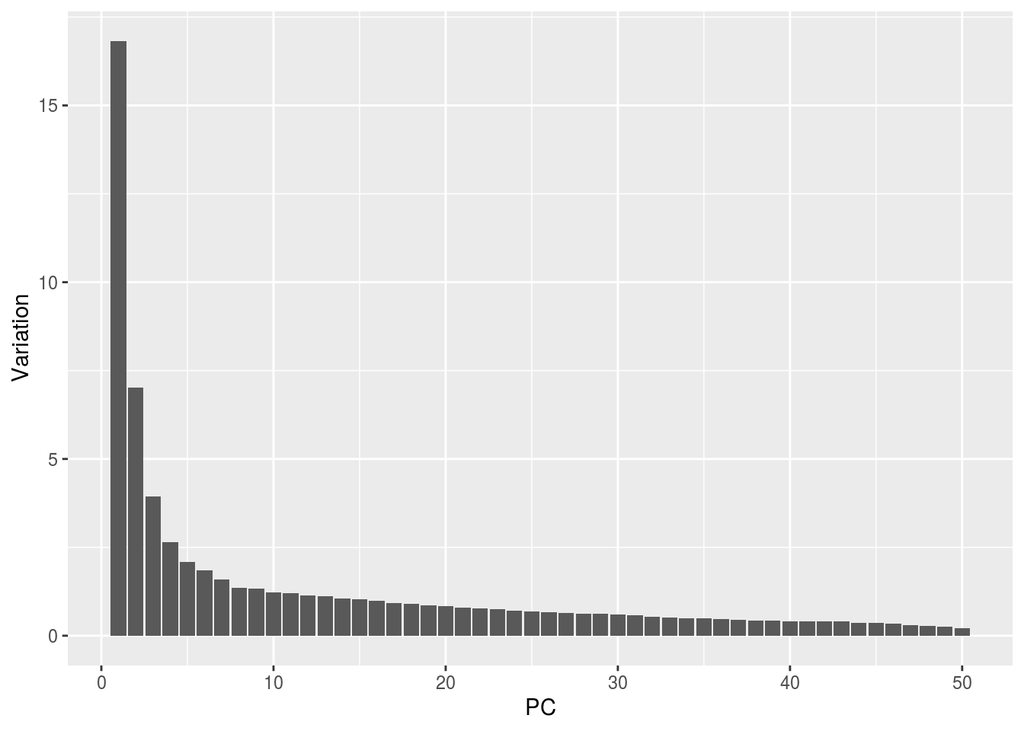

```r
pca1 <- prcomp(mat)

d_sdev = tibble(
  PC = 1:length(pca1$sdev),
  SDev = pca1$sdev,
  Variation = pca1$sdev ** 2
)

ggplot(d_sdev, aes(x = PC, y = Variation)) +
  geom_bar(stat = "identity")
```

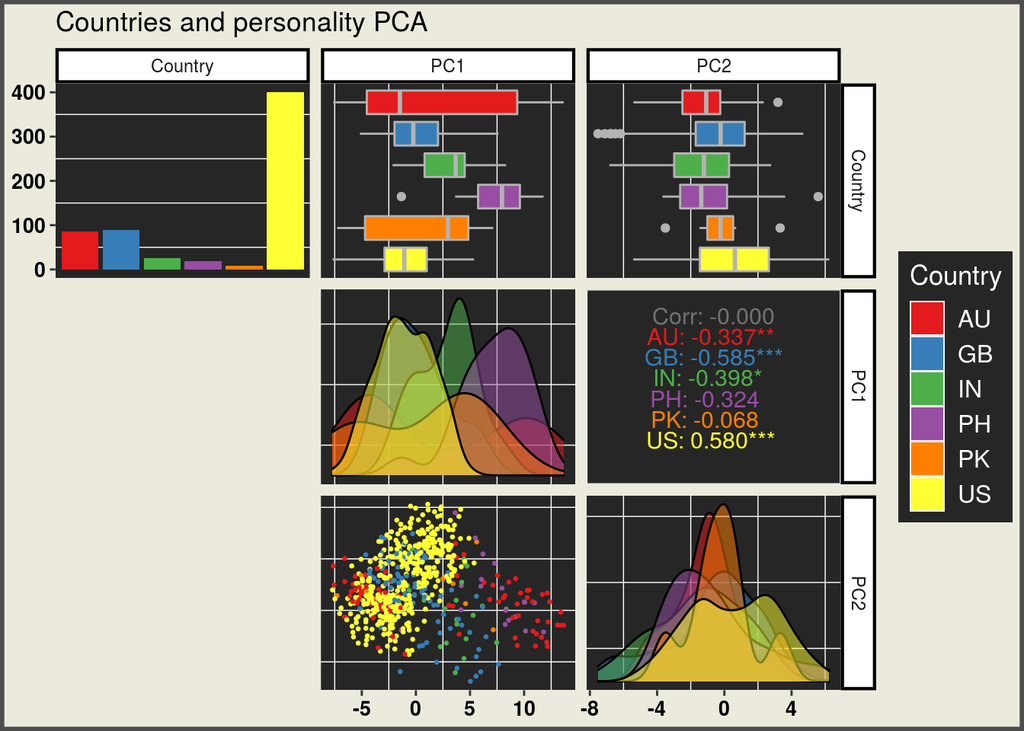

```r
a_idrow = a_row %>%
  rownames_to_column("Id")

pca_df = bind_cols(a_idrow, as_tibble(pca1$x[a_idrow$Id, ])) %>%
  select("Country", 4:10)

pairs <- ggpairs(pca_df, aes(color = Country), title = "Countries and personality PCA",
        columns =  1:3, legend = c(1,1), showStrips = TRUE,
        upper = list(combo = wrap("box_no_facet", color = "gray70"),
                     continuous = function(data, mapping, ...){
                       ggally_cor(data=data, mapping = mapping, size = 4,justify_labels = "left")+theme(panel.grid.major=element_blank())
                     }),
        diag = list(discrete="barDiag",
                    continuous = wrap("densityDiag", alpha=0.5)),
        lower= list(discrete = "blank",
                    continuous = wrap("points", size = 0.5),
                    combo="blank"))+
  scale_color_brewer(palette = "Set1")+
  scale_fill_brewer(palette = "Set1")+
  theme(panel.background = element_rect(fill = "gray15"))+
  theme(plot.background = element_rect(fill = "#EBEADC", colour = "gray30", size = 2))+
  theme(legend.background = element_rect(fill= "gray15"),legend.text = element_text(color = "white", size = 12),
          legend.title = element_text(color="white", size = 13))+
  theme(axis.text.x = element_text(face = "bold", color = "black",
                           size = 10),
          axis.text.y = element_text(face = "bold", color = "black",
                           size = 10))+
  theme(panel.grid.major = element_blank())+
  theme(
   strip.background = element_rect(
     color="black", fill="white", size=1.5, linetype="solid"))

pairs
```

```r
ggsave("kodutoo_PCA_pairs.png", pairs, width = 30, height =25, units = "cm")
```

Scree-plotist näeme, et esimesed kaks komponenti seletavad üsna suure osa variatsioonist. Samale viitab ka ggpairs plot, kus ainult esimese peakomponendi puhul on näha selgemat riikide eristumist. Täpsemalt on näha, et US ja GB (mis kattuvad peaaegu üks-ühele) eristuvad IN-st ja PH-st. Mediaani poolest erinevad GB ja US ka PK-st, kuid PK jaotus on väga laili venitatud ning seega tugevat eristumist raskem väita. Samuti on näha, et esimese ja teise komponendi skooride vaheline suhe on US puhul positiivne (PC1 tõustes tõuseb ka PC2) kuid teiste riikide puhul negatiivne. Huvitav, et vastupidine on suhe ka GB ja AU-ga võrreldes. Järgnevalt oleks mõistlik vaadata, kuidas küsimused (või küsimuste grupid) kaardistuvad nendele telgedele, et saada sisulisemat sissevaadet, mida need teljed (või kõige informatiivsem esimene telg) ikkagi esindavad.

```r
set.seed(2)

library(Rtsne)
library(tidyverse)
library(ggplot2)

load("16PF.RData", verbose = TRUE)
```

```
## Loading objects:
##   mat
##   a_row
##   a_col
```

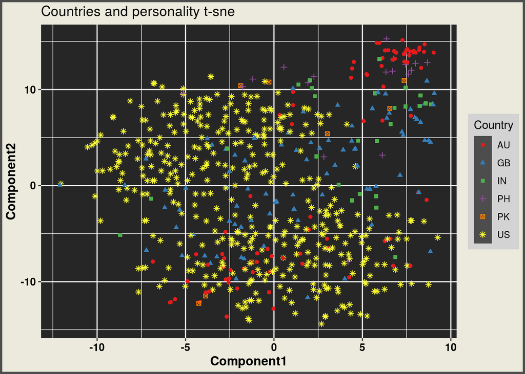

```r
tsne = Rtsne(mat, perplexity = 30)

d_tsne = tsne$Y
rownames(d_tsne) = rownames(mat)
colnames(d_tsne) = c("Component1", "Component2")

d_idrow2 = a_row %>%
  rownames_to_column("Id") %>%
  select(1:2)

tsne_df = bind_cols(d_idrow2, as_tibble(d_tsne[d_idrow2$Id, ]))

tsne_plot <- ggplot(tsne_df, aes(x = Component1, y = Component2, color = Country, shape = Country)) +
  geom_point()+
  ggtitle(label = "Countries and personality t-sne")+
  scale_color_brewer(type="qual", palette = "Set1")+
  theme(panel.background = element_rect(fill = "gray15"))+
  theme(plot.background = element_rect(fill = "#EBEADC", colour = "gray30", size = 2))+
  theme(legend.background = element_rect(fill= "lightgray"),
        legend.key=element_rect(fill = "gray30"))+
  theme(axis.text.x = element_text(face = "bold", color = "black",
                           size = 10),
          axis.text.y = element_text(face = "bold", color = "black",
                           size = 10))+
    theme(axis.title.x = element_text(face = "bold", color = "black",
                           size = 12),
          axis.title.y = element_text(face = "bold", color = "black",
                           size = 12))
tsne_plot
```

```r
ggsave("tsne_plot.png", tsne_plot, width = 25, height = 25, units = "cm")
```

Kuigi pilt muutub igal t-sne jooksutamisel, on alati näha PH ja natuke vähem üheselt selgelt ka IN eraldi grupeerumist US-ist, mis kinnitab ka eelnevate meetodite leidusid. Samuti on alati näha, et AU puhul moodustub 2 üksteisest selgelt eraldi olevat gruppi.

## Ülesanne 5

Failis `spotify_foreign.RData` on samasugused andmed aga välisartistide kohta. Proovi sealt välja tuua mõni sinu arvates huvitav seos ühe visualisatsiooniga. Esitada tuleks nii graafi genereeriv kood kui ka selgitus, mida te pildilt välja lugesite. Pildi puhul hindan, milliseid võtteid te olete kasutanud pildi ettevalmistamisel, kasutatud võiks olla vähemalt üks element kõigest järgnevast.

- On leitud sobiv punktide paigutus
- On muudetud tippude graafilisi omadusi
- On muudetud servade graafilisi omadusi
- On näidatud ära huvipakkuvamad tipud nime või mõne muu tekstiga
- On kasutatud graafi algoritme, andmete eeltöötluseks või graafiliste elementide lisamiseks

Lisaks tehnilisele poolele hindan järelduse ja graafiku kokkulangevust ning graafiku visuaalset vormistust.

```r
library(tidyverse)
library(tidygraph)
library(ggraph)
library(igraph)
load("spotify_foreign.RData", verbose = T)
```

```
## Loading objects:
##   nodes_foreign
##   edges_foreign
```

```r
edges_foreign = edges_foreign %>%
  rename(from = ArtistName1, to = ArtistName2)

g = tbl_graph(nodes = nodes_foreign, edges = edges_foreign, node_key = "ArtistName", directed = F)

net <- g %>%
    activate(edges) %>%
    mutate(`Edge Centrality` = centrality_edge_betweenness()) %>%
    activate(nodes) %>%
    filter(ArtistGenre == "hip-hop") %>%
    mutate(CC = group_components()) %>%
    filter(CC==1) %>%
    filter(!node_is_isolated()) %>%
    mutate(`Louvain Grouping` = as.factor(group_louvain())) %>%
    mutate(`Node Centrality Betweenness` = centrality_betweenness(weights = nTracks, directed = FALSE)) %>%
    ggraph(layout = "kk") +
    geom_edge_link(aes(width = nTracks, color = `Edge Centrality`))+
    geom_node_point(aes(fill = `Louvain Grouping`, size = `Node Centrality Betweenness`, alpha = ArtistPopularity), shape = 21)+
    geom_node_label(aes(label = ArtistName, fill = `Louvain Grouping`, alpha = ArtistPopularity), repel = T, color = "white", show.legend = c(alpha = F))+
    scale_edge_color_gradientn(colors = c(low = "white", mid = "red", high = "blue"))+
    scale_fill_brewer(type="qual", palette = "Set1")+
    theme(panel.background = element_rect(fill = "black"))+
    theme(plot.background = element_rect(fill = "lightgray", colour = "gray30", size = 2))+
    theme(legend.background = element_rect(fill= "black", colour = "#D100FF", linetype = "dashed"),
          legend.box = "horizontal", legend.text = element_text(color = "white", size = 12),
          legend.title = element_text(color="white", size = 13),
          legend.key=element_rect(fill = "#FEF8C0"),
          legend.position = c(0.45,0.97), legend.justification = c(1, 1))+
    theme(axis.text.x = element_blank(),
            axis.text.y = element_blank())+
      theme(axis.title.x = element_blank(),
            axis.title.y = element_blank())+
    scale_size(range = c(3,8))+
    scale_edge_width(range = c(1, 3))+
    scale_alpha(range= c(0.3,1))+
    guides(fill=guide_legend(ncol=3), alpha = guide_legend(ncol=2, title = "Artist Popularity"), size = guide_legend(ncol=3))

ggsave("kodutoo_network1.png", net, width = 50, height = 30, units = "cm")
```